# IPython Notebook

Interactive web-based computing, data analysis, and documentation.

## Outline

- What is the IPython Notebook?
- Top features.
- Running bash, R, and other languages.
- Remote execution on your favorite cluster

[figure not shown]

## What is the IPython Notebook?

Web-based interactive `Python` programming environment.

- One document for code and output
- Run locally and remote
- Document process
- Share results

### Does not separate code and text

- Data structure ouput
- Inline plots
- [Literate programming](http://en.wikipedia.org/wiki/Literate_programming)
  - Conversation, telling a data story
- Great for *iterative* programming.
  - Data analysis
  - Quick scripts
  - Prototyping

### Locally and Remote

- Run locally
- Connect to the cloud (e.g [AWS](http://aws.amazon.com/))
- Connect to supercomputer (e.g. [JANUS](https://www.rc.colorado.edu/services/compute/janus))
- Add compute power:
  - [mpi4py](http://mpi4py.scipy.org/)
  - [IPython Parallel](http://ipython.org/ipython-doc/dev/parallel/)
  - [spark](http://spark.incubator.apache.org/) MapReduce
  - [Numbapro](http://docs.continuum.io/numbapro/) GPU
  - ...

### Documentation and Sharing

[figure not shown]

### It's just a `json` file

```python
with open('02_notebooks.ipynb','r') as infile:
    tmp = infile.read()
    inx = tmp.find("It's just a `json` file")

print tmp[inx-200:inx+200]
```

[output not shown]

### Perspective

- Fernando Perez: [The IPython notebook: a historical retrospective](http://blog.fperez.org/2012/01/ipython-notebook-historical.html)
  - 2001: `IPython` begins.
  - 2005: Started working on an early prototype.
  - 2011: First official release.
- Similar to
  - [Mathematica notebooks](http://www.wolfram.com/mathematica/)
  - [Maple worksheets](http://www.maplesoft.com/products/Maple/)
  - [Sage notebook](http://www.sagenb.org/)

### Keyboard Shortcuts

[figure not shown]

### `Markdown` and `Latex`

- `Markdown`
- Latex $y = \sqrt{a + b}$

### Images

```
<img src='images/monty-python.png' width="400">
```

This is an image:

[figure not shown]

### Video

```python
from IPython.display import YouTubeVideo
YouTubeVideo('F4rFuIb1Ie4', start=2400, width=600, height=400)
```

### Embeded plots

```python
import numpy as np
x = np.random.randn(10000)
```

What does $x$ look like?

```python
x
```

```
array([-0.19509931,  1.06224835,  0.31786405, ..., -0.11654655,
        0.07016358, -0.20161112])
```

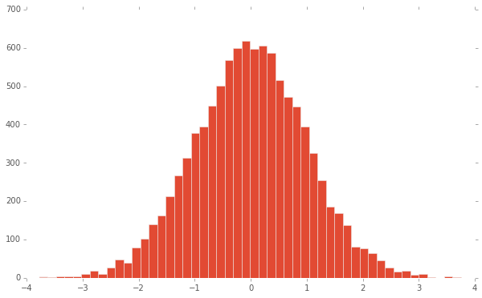

```python
%matplotlib inline
import matplotlib.pyplot as plt
plt.hist(x, bins=50)
plt.show()
```

### Customizable

- Custom `CSS`
- Custom `javascript` libraries
- Create your own output format.
- Tools and workflow

### Magic Commands

- Built-in useful functions
- `%` line commands
- `%%` cell commands

### Write to a file.

```python
%%writefile example.py

def hello():
    print 'hello'
```

```
Writing example.py
```

### Load a file into a Notebook.

```python
%load example.py
```

```python
def hello():
    print 'hello'
```

```python
hello()
```

```
hello
```

### Execute a file

Great for working with your own files.

```python
%%writefile example.py

def get():
    return 10

A = get()
```

```
Overwriting example.py
```

```python
%run example.py

print A
```

```
10
```

**Notice** that `A` is now available.

### `import` and `reload`

Great for working with your own `modules`.

```python
import example as ex
reload(ex)

print ex.get()
```

```
10
```

### Other Languages: Bash

```python
%%bash
ls -l
```

```
total 10640
-rw-r--r--   1 mlunacek  staff    22688 Apr 11 08:21 00_overview.ipynb
-rw-r--r--   1 mlunacek  staff     2677 Apr 11 08:21 00_overview.py
-rw-r--r--   1 mlunacek  staff    66938 Apr 11 05:08 01_introduction.ipynb
-rw-r--r--   1 mlunacek  staff    16321 Apr 11 05:08 01_introduction.py
-rw-r--r--   1 mlunacek  staff    29132 Apr 11 09:15 02_notebooks.ipynb
-rw-r--r--   1 mlunacek  staff     6296 Apr 11 09:02 02_notebooks.py
-rw-r--r--   1 mlunacek  staff    87735 Apr 11 04:27 03_numpy.ipynb
-rw-r--r--   1 mlunacek  staff     7467 Apr 11 04:27 03_numpy.py
-rw-r--r--   1 mlunacek  staff   985587 Apr 11 04:28 04_matplotlib.ipynb
-rw-r--r--   1 mlunacek  staff    16536 Apr 11 04:28 04_matplotlib.py
-rw-r--r--   1 mlunacek  staff    65314 Apr 11 04:27 05_pandas.ipynb
-rw-r--r--   1 mlunacek  staff     7194 Apr 11 04:27 05_pandas.py
-rw-r--r--   1 mlunacek  staff  4040701 Apr 11 04:27 06_sklearn.ipynb
-rw-r--r--   1 mlunacek  staff    24970 Apr 11 04:27 06_sklearn.py
-rw-r--r--   1 mlunacek  staff    26192 Apr 11 05:01 07_parallel.ipynb
-rw-r--r--   1 mlunacek  staff     2417 Apr 11 05:01 07_parallel.py
drwxr-xr-x  19 mlunacek  staff      646 Apr 10 19:24 data
-rw-r--r--   1 mlunacek  staff       40 Apr 11 09:15 example.py
-rw-r--r--   1 mlunacek  staff      219 Apr 11 09:16 example.pyc
drwxr-xr-x  21 mlunacek  staff      714 Apr 11 05:51 img
```

```python
files = !ls -l # But glob is a better way
print files
```

[output not shown]

### Other Languages: R

- Requires [rpy2](http://rpy.sourceforge.net/)
- More [examples](http://nbviewer.ipython.org/github/ipython/ipython/blob/3607712653c66d63e0d7f13f073bde8c0f209ba8/docs/examples/notebooks/rmagic_extension.ipynb)

```python
%load_ext rmagic
%reload_ext rmagic
```

```python
X = np.array([0,1,2,3,4])
Y = np.array([3,5,4,6,7])

print X, Y
```

```
[0 1 2 3 4] [3 5 4 6 7]
```

```python
%Rpush X Y
res = %R lm(Y~X)$coef
print res
```

```
[ 3.2  0.9]
```

```python
%%R
a = lm(Y~X)
a$coef
```

```
(Intercept)           X
        3.2         0.9
```

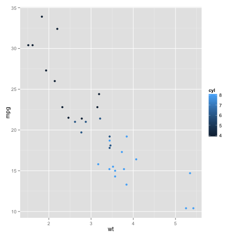

```python
%%R
library(ggplot2)
p <- ggplot( mtcars, aes( x = wt, y = mpg, color = cyl)) + geom_point()
print(p)
```

### Keep it all together

```python
%%writefile example.cpp
#include <iostream>

int main(){
    std::cout << "hello from c++" << std::endl;
}
```

```
Writing example.cpp
```

```python
%%bash
g++ example.cpp -o example
./example
```

```
hello from c++
```

## Running on a Remote Cluster

Steps:

- Login

  ```
    username@hostname
  ```

- Start an iteractive job (optional)
- Start the notebook:

  ```
    `ipython notebook --no-browser`
  ```

- Create an `ssh` tunnel to the node

  ```
    ssh -L localport:hostname:remoteport -f -N username@hostname
  ```

Automate:

- [starcluster](http://star.mit.edu/cluster/) for AWS
- [saga-project](http://saga-project.github.io/)
- Roll your own with [paramiko](http://www.lag.net/paramiko/) (example remotenb)

```python
%%bash

which notebook.py
notebook.py --help
```

## NBconvert examples

- HTML
- PDF (print)
- Slides
- Dynamic Slides
- ReStructured Text ([sphinx](http://sphinx-doc.org/))